# Practical 2: Data Visualisation

### Question 16

```r
which.max(Smarket$Volume[1:200])
```

```
## [1] 170
```

```r
max(Smarket$Volume[1:200])
```

```
## [1] 2.33083
```

So the 170th day had the highest trade volume of 2.33.

### Question 17

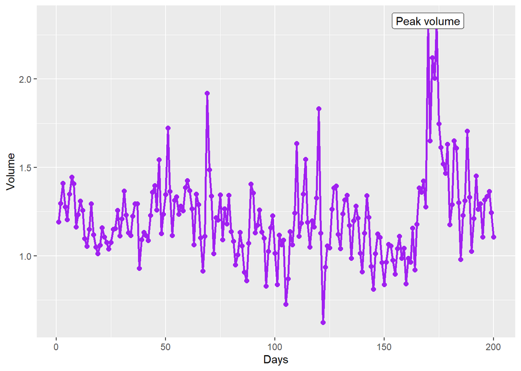

```r
line_plot_2 +
  geom_label(aes(x = 170, y = 2.33083, label = "Peak volume"))
```

### Question 18

```r
library(magrittr)
baseball <- Hitters %>%
  filter(., !is.na(Salary)) %>%
  mutate(Cat_Sal = cut(x = Salary, breaks = 3, labels = c("Well-Off",
                                                          "Rich",
                                                          "Super Rich")),
         Prop_HmRun = CHmRun/CHits)
```

### Question 19

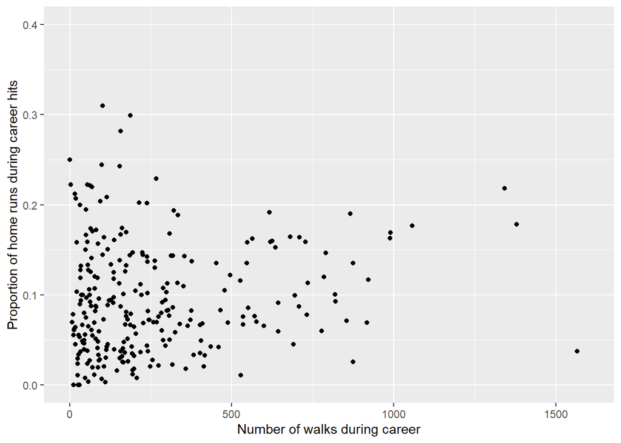

```r
baseball_plot <- ggplot(data = baseball, aes(x = CWalks, y = Prop_HmRun)) +
  geom_point() +
  ylim(0, 0.4) + xlim(0, 1600) +
  labs(x = "Number of walks during career",
       y = "Proportion of home runs during career hits")

baseball_plot
```

### Question 20

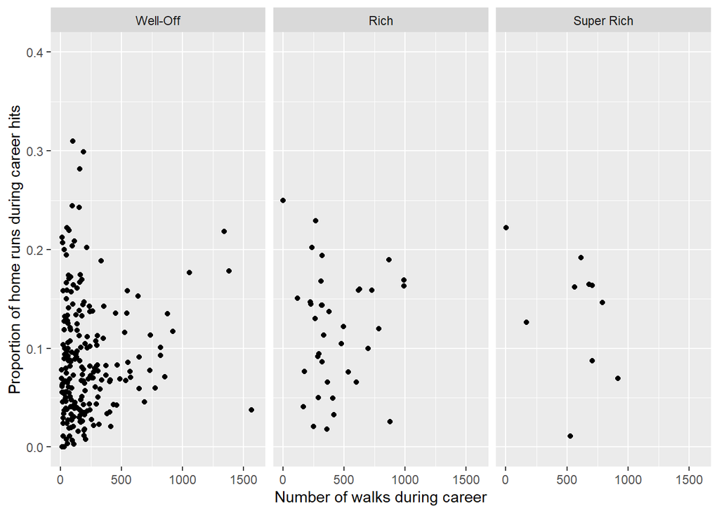

```r
baseball_plot + facet_wrap(vars(baseball$Cat_Sal))
```

### Question 21

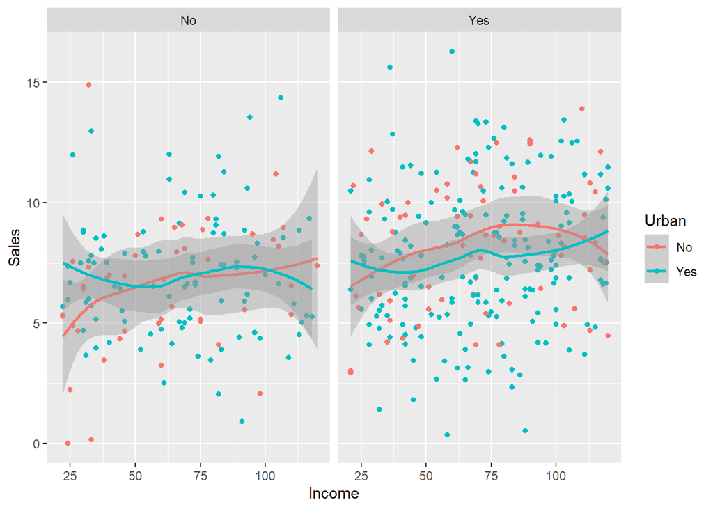

```r
Carseats %>%
  ggplot(data = ., aes(x = Income, y = Sales, col = Urban)) +
  geom_point() +
  facet_wrap(vars(Carseats$US)) +
  geom_smooth()
```

Tadaaa! A beautiful plot that shows the relation between community income and car sales while taking into account whether the area is urban or not and whether the shop is in the USA. There does not seem to be a relation between the two variables. Noticeable is however that there seem more car sales in the US. This could possibly be explained by to the fact that it is a large country with terrible public transportation. Hence, everyone needs to have a car.